Toggle Input Cells

# Crime Analysis Examples

This notebook demonstrates how to use Ambry and Pandas for exploratory crime analysis. The analysis will examine six years of data that was aggregated by SANDAG and processed by the [San Diego Regional Data Library](http://sandiegodata.org). The data is published in CSV and shapefile form at the [Library's data repository](http://data.sandiegodata.org/dataset/clarinova_com-crime-incidents-casnd-7ba4-extract), but this analysis uses an updated dataset that is only available through Ambry.

Ambry is our data package management system, which is currently in alpha testing, with an expected public release in Spring of 2014.

## Initializing the Data

The first step is to get the data. We'll use the Ambry library to get two data files, link them together and run a query, which will place data into a Pandas DataFrame.

```python
import numpy as np
import pandas as pd
import matplotlib.pyplot as plt
import ambry

l  =  ambry.ilibrary()

incidents = l.get('clarinova.com-crime-incidents-casnd-linked-crimes').partition
placestats = l.get('clarinova.com-places-casnd-areastats').partition
```

In Ambry, we can use the library to find datasets and inspect their columns. For instance, here are the fields in the`incidents` table. The code `incidents.table` would give you the schema for the tables, but we'll omit the output to leave space for the analysis outputs.

In Ambry, datasets are Sqlite files, so we can connect them together and run queries across them.

```python
incidents.attach(placestats, 'placestats')
```

```
'placestats'
```

Now, the `incidents` database has an attached database for place statistics, so we can get population quantities and densities and full community names. The next step is to query the combined datasets and do some processing to get specific names for areas. After defining the query, you can see how simple it is to get the data into a Pandas DataFrame.

The Placestats data base has an `areastats` table that has records for neighborhoords, communities, cites and council districts in San Diego county, although the communities and neighborhods are only specified for the city of San Diego, So, the `WHERE community != '-'` means that all of these records will be for San Diego city, which is about half of the crime records for the county.

The `LEFT JOIN` clauses attach parts of the `areastats` table to codes in the crime dataset. The library uses 6 charater codes for each of the cities and neighborhoods. These codes are memorable once you learn them -- for instance, the codes for "Pacific Beach" is "SanPCF" -- but they are difficult to remember when you are dealing with a lot of them.

```python
q = """
SELECT crimes.*,
    city_stats.pop as city_pop, city_stats.land as city_area,
    CAST(city_stats.pop AS REAL)/ CAST(city_stats.land AS REAL) as city_density,
    community_stats.pop as community_pop, community_stats.land as community_area, community_stats.name as community_name,
    CAST(community_stats.pop AS REAL)/ CAST(community_stats.land AS REAL)*1000000 as community_density
FROM crimes
LEFT JOIN placestats.areastats AS city_stats ON city_stats.type = 'city' AND city_stats.code = crimes.city
LEFT JOIN placestats.areastats AS community_stats ON community_stats.type = 'community' AND community_stats.code = crimes.community
WHERE community != '-'
"""

inct = incidents.select(q).pandas
inct.head(5)
```

|  | id | agency | legend | description | type | datetime | year | month | hour | dow | geoid | placens | address_id | city_name | community | neighborhood | council | city | segment_source_id | x |  |
| --- | --- | --- | --- | --- | --- | --- | --- | --- | --- | --- | --- | --- | --- | --- | --- | --- | --- | --- | --- | --- | --- |
| 0 | 38 | San Diego Police, CA | FRAUD | FRAUD | CRIME CASE | 2007-01-01 00:00:00.000000 | 2007 | 1 | 0 | 1 | 060730031132006 | 2411782 | 434817 | San Diego | SanENC | SanALT | San004 | SndSAN | 35903 | 6309870.85443 | ... |
| 1 | 39 | San Diego Police, CA | FRAUD | FRAUD | CRIME CASE | 2007-01-01 00:00:00.000000 | 2007 | 1 | 0 | 1 | 060730078003010 | 2411782 | 496084 | San Diego | SanPCF | SanPAC | San002 | SndSAN | 32148 | 6260281.45530 | ... |
| 2 | 40 | San Diego Police, CA | FRAUD | FRAUD | CRIME CASE | 2007-01-01 00:00:00.000000 | 2007 | 1 | 0 | 1 | 060730098014000 | 2411782 | 394976 | San Diego | SanNAV | SanSNC | San007 | SndSAN | 48889 | 6318195.11771 | ... |
| 3 | 41 | San Diego Police, CA | FRAUD | FRAUD | CRIME CASE | 2007-01-01 00:00:00.000000 | 2007 | 1 | 0 | 1 | 060730082001003 | 2411782 | 487957 | San Diego | SanLAJ | SanLAJ | San001 | SndSAN | 25590 | 6246487.76382 | ... |
| 4 | 42 | San Diego Police, CA | VANDALISM | VANDALISM ($400 OR MORE) | CRIME CASE | 2007-01-01 00:00:00.000000 | 2007 | 1 | 0 | 1 | 060730089022002 | 2411782 | 686573 | San Diego | SanMSS | SanMST | San007 | SndSAN | 157427 | 6279420.81833 | ... |

5 rows × 33 columns

```python
inct['id'].count()
```

```
403919
```

Now we've got 400,000 records for crime incidents in San Diego, and we can start to visualize them.

# Time Series Visualizations

The first visualizations will look at all crime incidents over the entire period by hour of day and then day of week, as line charts. Then we'll look at a different way to view the same data. First, here are the number of crimes, by category, by hour.

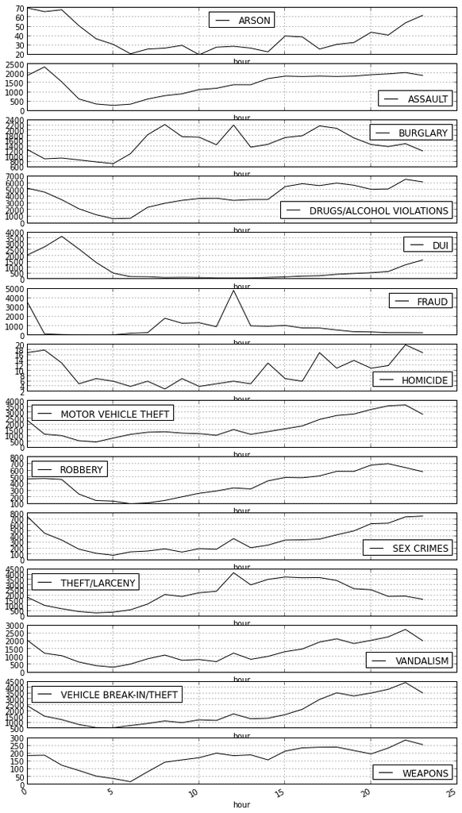

```python
dfm= inct.groupby(['hour','legend'])
counts = dfm.count()
cus = counts.unstack(1)
uscounts = cus['id']
ax = uscounts.plot(subplots=True, figsize=(10,20), colormap='jet')
```

One of the interesting things to note is the uptick at noon for many of the crimes. This uptick is most likely due to time values not provided being encoded as 12:00 noon.

Here is a similar set of charts, but by day of week instead of hour of day.

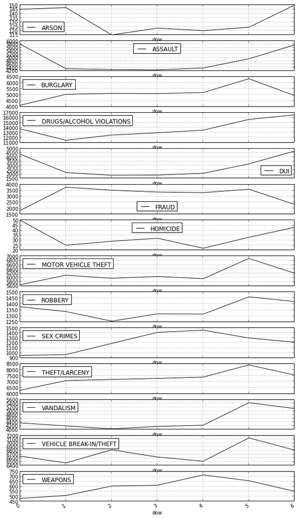

```python
dowg = inct.groupby(['dow','legend'])
dowcounts = dowg.count()
dowuns = dowcounts.unstack(1)
dowcounts = dowuns['id']
ax = dowcounts.plot(subplots=True, figsize=(10,20))
```

## Hour and Day of Week Heatmaps

In the previous charts, the Y axis scale isn't very important -- you probably were more interested in the relative changes in the number of crimes than in the absolute number. By dispensing with the numeric asix and replacing it with a color, we can combine both charts and make them more visually appealing, with a heatmap.

Here is the function to create the grid of heatmaps.

```python
from math import ceil

def plot_heat_grid(df, legends = None):

    if not legends:
        legends = sorted([ l for l in df.legend.unique() if l.strip() and l not in ('-', 'ARSON','HOMICIDE') ])

    c = len(legends)
    ncols = 4.
    nrows = ceil(float(c)/ncols)

    cmap = plt.get_cmap('YlOrRd')

    fig, axes = plt.subplots(nrows=int(nrows), ncols=int(ncols), figsize=figsize(10,10), squeeze=True, sharex=False, sharey=False)

    fig.set_size_inches(ncols*2.5,nrows*2.5)
    axes = axes.ravel() # Convert 2D array to 1D
    plt.tight_layout(h_pad=1)
    for i, legend in enumerate(legends):

        sub = df[df.legend == legend]
        heatg = sub.groupby(['dow','hour'])
        hgcounts = heatg.count()['id'].unstack('hour').fillna(0)

        # Converting to an array puts it into a for that
        # matplotlib expects. This probably only works b/c the
        # hours and days of week are 1-based indexes.
        axes[i].pcolormesh(array(hgcounts.T),cmap=cmap)
        axes[i].set_title(legend.title())
```

For the first grid, we'll look at crime types, across all of San Diego. The vertical axis is hour of day, and the horizontal axis is day of week, with Sunday being the area between 0 and 1, etc. The color indicates the number of crimes in that hour of the week, with red being larger than yellow. Note that each grid is scaled independently, so a red square in one heatmap is not comparable to a red square in another heatmap. This visualization is only for looking at the paterns of crimes over time.

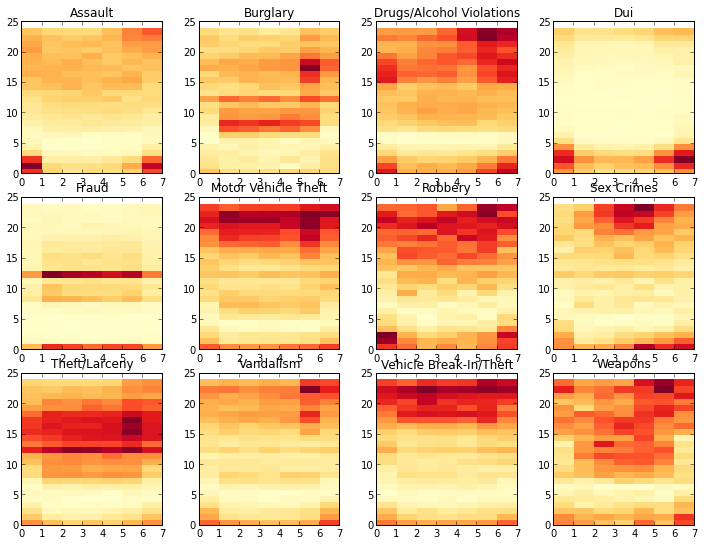

```python
plot_heat_grid(inct)
```

There are a lot of stories in this grid!

- The "12:00 default" is clearly visible in the Fraud and Theft heatmaps.
- Burglary, usually theft from a person's home, happens during the times that people are either at work, or out on a Friday evening.
- DUIs happen around when the bars close.
- Prostitution is most popular on Thursday evenings. ( Or that's when the vice squad likes to hit the town. )

The `plot_heat_grid` function can take a DataFrame that includes a subset of records, so we can select only one city or community to analyze. This will let us see if there are different patterns in other comminities.

But first, we need to get the community codes to be able to select one. Here is a list of all community codes, with the community name and population.

```python
inct[['community','community_name', 'community_pop']].drop_duplicates().sort('community_pop', ascending=False)
```

|  | community | community_name | community_pop |
| --- | --- | --- | --- |
| 13 | SanCLA | Clairemont Mesa | 77873 |
| 8 | SanMDC | Mid-City:City Heights | 74062 |
| 7 | SanMIR | Mira Mesa | 72761 |
| 14 | SanSKY | Skyline-Paradise Hills | 67273 |
| 22 | SanUNV | University | 63098 |
| 24 | SanOAT | Otay Mesa-Nestor | 60544 |
| 11 | SanSOT | Southeastern San Diego,Southeastern | 57358 |
| 2 | SanNAV | Navajo | 48313 |
| 0 | SanENC | Encanto Neighborhoods,Southeastern | 47361 |
| 21 | SanGRE | Greater North Park | 45697 |
| 53 | SanRNC | Rancho Penasquitos | 42779 |
| 200 | SanRAN | Rancho Bernardo | 40096 |
| 1 | SanPCF | Pacific Beach | 39849 |
| 45 | SanPEN | Peninsula | 38269 |
| 39 | SanMID | Mid-City:Eastern Area | 37348 |
| 18 | SanUPT | Uptown | 37279 |
| 506 | SanCAR | Carmel Valley | 33580 |
| 6 | SanDOW | Downtown | 31759 |
| 155 | SanLIN | Linda Vista | 31648 |
| 47 | SanTIR | Tierrasanta | 30447 |
| 3 | SanLAJ | La Jolla | 29018 |
| 108 | SanSNS | San Ysidro | 27869 |
| 46 | SanSER | Serra Mesa | 20959 |
| 64 | SanCOL | College Area | 20794 |
| 72 | SanSCI | Scripps Miramar Ranch | 19323 |
| 4 | SanMSS | Mission Valley | 18947 |
| 148 | SanMDS | Mid-City:Normal Heights | 15748 |
| 137 | SanGRT | Greater Golden Hill | 15461 |
| 149 | SanOTM | Otay Mesa | 15140 |
| 187 | SanMIL | Military Facilities | 15015 |
| 20 | SanMII | Mid-City:Kensington-Talmadge | 13816 |
| 183 | SanOCN | Ocean Beach | 12953 |
| 1206 | SanCRM | Carmel Mountain Ranch | 12021 |
| 179 | SanMRM | Miramar Ranch North | 11953 |
| 222 | SanSAB | Sabre Springs | 11256 |
| 1024 | SanTRR | Torrey Highlands | 7725 |
| 225 | SanBLA | Black Mountain Ranch | 6653 |
| 97 | SanTOR | Torrey Pines | 6597 |
| 235 | SanPAC | Pacific Highlands Ranch | 6507 |
| 16 | SanKER | Kearny Mesa | 6417 |
| 57 | SanMDW | Midway-Pacific Highway | 5829 |
| 8110 | SanTOE | Torrey Hills | 5015 |
| 116 | SanMSH | Mission Beach | 4659 |
| 172 | SanBAR | Barrio Logan | 4259 |
| 5987 | SanRAO | Rancho Encantada | 2543 |
| 268 | SanMIS | Mission Bay Park | 2076 |
| 8715 | SanDEL | Del Mar Mesa | 1159 |
| 156 | SanOLD | Old Town San Diego | 832 |
| 1873 | SanFAR | Fairbanks Ranch Country Club | 729 |
| 8412 | SanLOS | Los Penasquitos Canyon | 707 |
| 14558 | SanNCU | Ncfua Subarea Ii | 536 |
| 13988 | SanVID | Via De La Valle | 353 |
| 3863 | SanTIJ | Tijuana River Valley | 329 |
| 401 | SanBAL | Balboa Park | 249 |
| 12026 | SanSAN | San Pasqual | 195 |
| 750 | SanRES | Reserve | 61 |
| 997 | SanEST | East Elliott | 0 |

57 rows × 3 columns

Now we can see the patterns for only Pacific Beach. Pacific Beach is about 35% quiet family neighborhoods and the remainder is young singles and a rowdy strip of clubs, bars and tatoo parlors. The family neighborhoods have some of the lowest crime rates in the city, and the "Whiskey Row" has some of the highest.

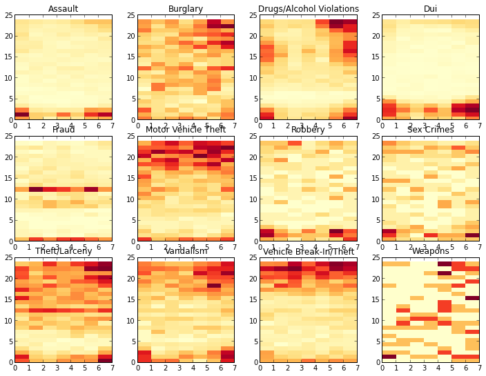

```python
plot_heat_grid(inct[inct.community == 'SanPCF'])
```

This is the Downtown area. The area has an increasing number of residents, but most of the people are there for business, a low crime activity, or nightlife, a high-crime activity. The result is that the patters are similar to Pacific Beach.

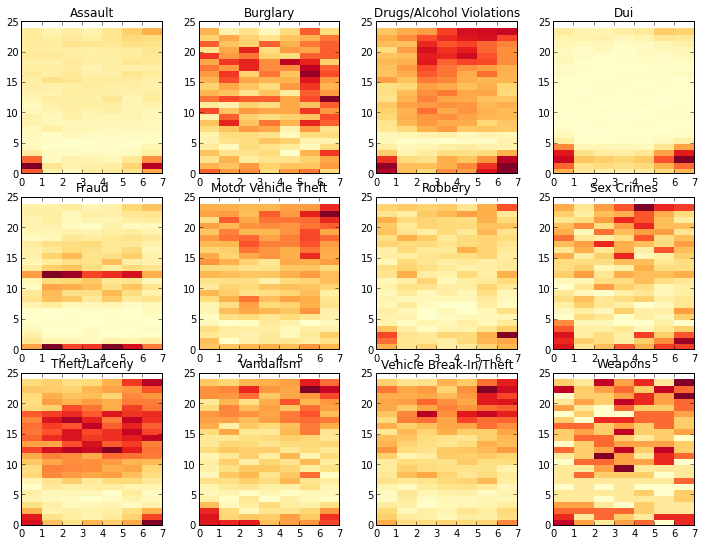

```python
plot_heat_grid(inct[inct.community == 'SanDOW'])
```

Here is North Park, another high-intensity nightlife area, with a specialization in prostitution. The "Sex Crimes" category has a variety of specific crimes, and in the previous maps they are all contributing, and since some of the can happen throughout the day, the maps are difuse. In North Park, prostitution dominates, and it swamps the other sex crimes, so you see a strong pattern, with prostitution peaking on Wednesday evenings.

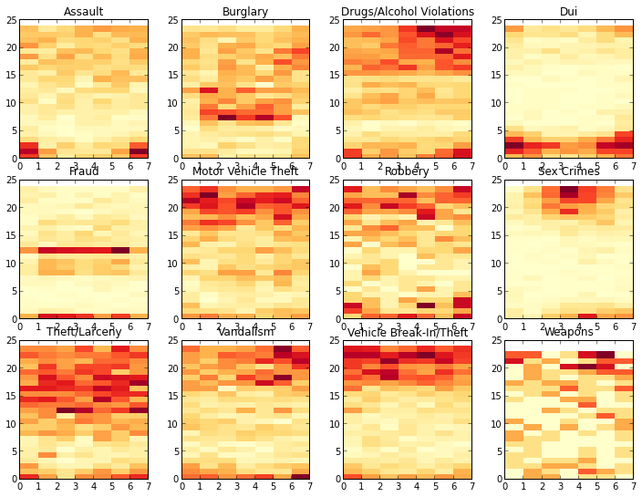

```python
plot_heat_grid(inct[inct.community == 'SanGRE'])
```

Here is the set of specific categories of sex crimes, across the whole city. "Other Sex Crime" is the catch all category that includes all of the kinky things that you don't even want to know about, and all of the really common things that you can't believe we still have laws about. Other sex crimes are varied, so there isn't a strong time component to it and there aren't strong patterns in the heat maps.

```python
category_counts = inct[['legend','description']].groupby(['legend','description']).count()
category_counts.loc['SEX CRIMES']
```

| description | legend | description |
| --- | --- | --- |
| OTHER SEX CRIME | 3559 | 3559 |
| PROSTITUTION | 3453 | 3453 |
| RAPE | 1473 | 1473 |

3 rows × 2 columns

Here are the counts for North Park. Unlike the rest of the city, it is much more tilted toward prostitution. Unfortunately, there isn't enough data to explore why it is most prevalent on Wednesdays.

```python
sangre_incidents = inct[inct.community == 'SanGRE']
category_counts = sangre_incidents[['legend','description']].groupby(['legend','description']).count()
category_counts.loc['SEX CRIMES']
```

| description | legend | description |
| --- | --- | --- |
| OTHER SEX CRIME | 148 | 148 |
| PROSTITUTION | 1371 | 1371 |
| RAPE | 86 | 86 |

3 rows × 2 columns

This sort of heat map analysis isn't always useful. La Jolla, which is one of the wealthiest zip codes in the country, with a lot of large estates with low poulation density and a very constrained nightlife district, has too few crimes to light up the heatmaps. The result is that there are no clear patterins in most of the maps, and some don't have any crimes at some times of day.

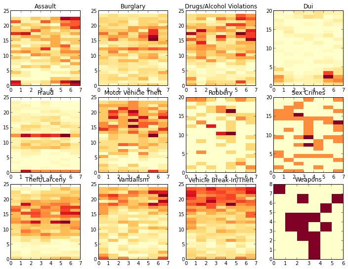

```python
plot_heat_grid(inct[inct.community == 'SanLAJ'])
```

## Comparing Communities

The preceeding analysis lets us see which of the crime types have interesting patterns. Now let's look at how those patterns vary across communities. There there are a lot of communities, we'll pick a selection of them. The selection includes the largest communities a few of the poorest and a few of the wealthy ones.

```python
# Get a list of all of the communities, ordered by population, so we can manually extract codes.
x = inct[['legend','community']]
#x = x[x.legend == 'SEX CRIMES']
x.groupby('community').count().sort('legend', ascending=False)


communities = ['SanDOW','SanMDC','SanPCF','SanSOT','SanGRE','SanCLA','SanUPT','SanENC','SanUNV','SanMID',
               'SanMIR','SanSKY','SanOAT', 'SanCOL', 'SanLAJ']
```

Here is a variant of the heat grid function, altered to display communities.

```python
def plot_heat_grid_community(df,  communities=None):

    if not communities:
        communities = sorted([ l for l in df.community.unique() if l.strip() and l not in ('-') ])

    c = len(communities)
    ncols = 5.
    nrows = ceil(float(c)/ncols)

    cmap = plt.get_cmap('YlOrRd')

    fig, axes = plt.subplots(nrows=int(nrows), ncols=int(ncols), figsize=figsize(10,10), squeeze=True, sharex=False, sharey=False)

    fig.set_size_inches(ncols*2,nrows*2)
    axes = axes.ravel() # Convert 2D array to 1D
    plt.tight_layout(h_pad=1)
    for i, community in enumerate(communities):

        sub = df[df.community == community]
        if not sub.empty:
            heatg = sub.groupby(['dow','hour'])

            hgcounts = heatg.count()['id'].unstack('hour').fillna(0)

            # Converting to an array puts it into a for that
            # matplotlib expects. This probably only works b/c the
            # hours and days of week are 1-based indexes.
            axes[i].pcolormesh(array(hgcounts.T),cmap=cmap)
            axes[i].set_title(community)
```

```python
inct.legend.unique()
```

```
array([u'FRAUD', u'VANDALISM', u'VEHICLE BREAK-IN/THEFT', u'BURGLARY',
       u'ROBBERY', u'THEFT/LARCENY', u'MOTOR VEHICLE THEFT', u'SEX CRIMES',
       u'DRUGS/ALCOHOL VIOLATIONS', u'ASSAULT', u'DUI', u'WEAPONS',
       u'ARSON', u'HOMICIDE'], dtype=object)
```

First up, Sex crimes, emphasizing prostitution. Most of the grids are spotty, indicating there are not enough incidents for proper analysis, with the exception of North Park, Downtown and Mid-City / City Heights.

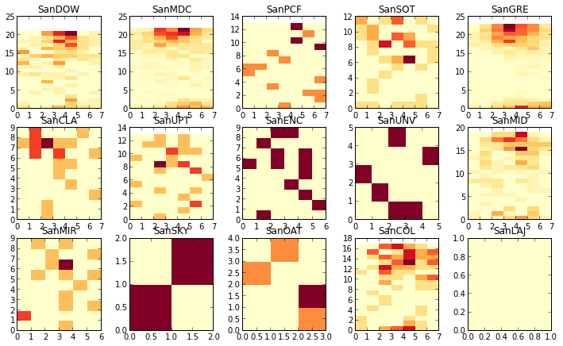

```python
plot_heat_grid_community( inct[ ( inct.legend == 'SEX CRIMES') & (inct.description == 'PROSTITUTION' ) ], communities=communities)
```

Burglary shows some interesting patterns -- several of the communities are missing the cluster of incidents in the middle of the workday, and some have much stronger Friday evenings. Our original analysis showed the workday and Friday evening patterns on the same heatmap, but it turns out they are independent, and occur in different communities.

A guess at the reason is that in the more affluent areas there are more people who work from home or maintain the home, so the burglars have to pick another time. A future analysis could link in Census data to verify this hypothesis.

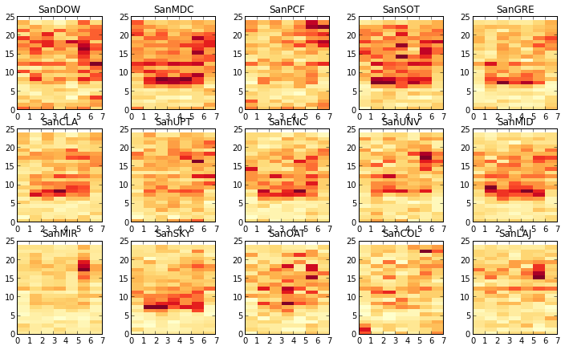

```python
plot_heat_grid_community( inct[inct.legend == 'BURGLARY'], communities=communities)
```

DUIs however, look pretty much the same everywhere, although some communities get started earlier. The communities that have more "noise" in the middle of the map, rather than being solid yellow, are ones that have fewer DUIs; in the comunities with a lot of DUIs, such as SanDOW and SanPCF the large number of nighttime DUIs swamps those during the day.

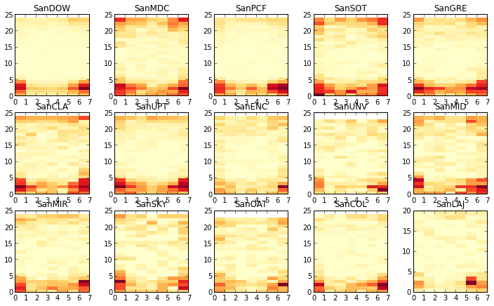

```python
plot_heat_grid_community( inct[inct.legend == 'DUI'], communities=communities)
```

The patterns for Theft are more subtle, but seem to be connected to whether the community has an active nightlife, where more of the interactions between people occur in the evening.

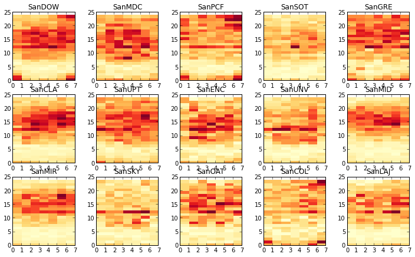

```python
plot_heat_grid_community( inct[inct.legend == 'THEFT/LARCENY'], communities=communities)
```